# Pekel data vs gage data

### Buffered/non-buffered streams; gage height/discharge

Here we use stream gage data to fill gaps in the coincident Pekel JRC Global Surface Water timeseries.

- Monthly data are used in both cases, limited to **HUC18020115**.
- 4-way comparison:
  - Discharge data vs. unbuffered data
  - Discharge data vs. buffered data
  - Gage height vs. unbuffered data
  - Gage height vs. buffered data

where ‘buffered’ data are Pekel data limited to 500m around each stream.

##### **Max monthly water extent - Pekel data for entire HUC**

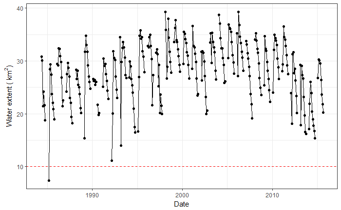

##### **Max monthly water extent - Pekel data limited to 500m buffered streams**

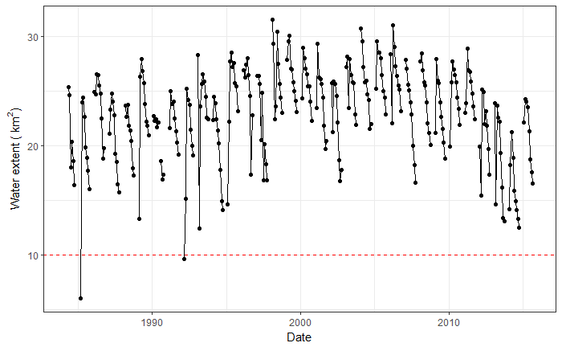

Given the noise in each time series, all data below the dashed red lines are simply removed and replaced with NA. (Should eventually be replaced by a more sophisticated noise removal process).

##### **Cleaned-up plot for entire HUC**

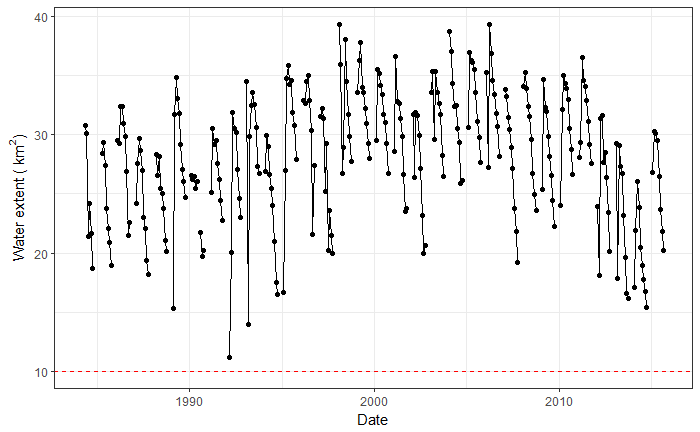

##### **Cleaned-up plot for buffered HUC**

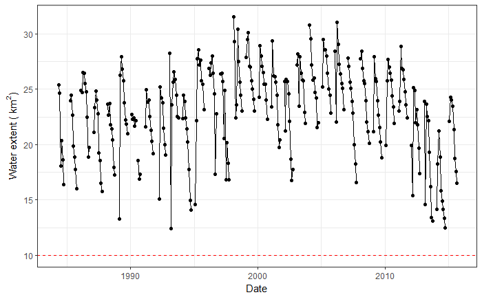

The plots show some differences in slope up until ~1995, but generally track each other well.

[output not shown]

##### **Correlation table**

Querying NWIS for monthly stream gage data and correlating with Pekel data (kendall tau) yields:

| Gage | Pekel data | Parameter | r |
| --- | --- | --- | --- |
| 11449500 | buffered | discharge | 0.4072524 |
| 11449500 | unbuffered | discharge | 0.3515155 |
| 11450000 | buffered | gage ht | 0.6922436 |
| 11450000 | unbuffered | gage ht | 0.6584630 |
| 11451000 | buffered | discharge | 0.4618802 |
| 11451000 | unbuffered | discharge | 0.4233668 |
| 11451100 | buffered | discharge | 0.4433432 |
| 11451100 | unbuffered | discharge | 0.3861636 |
| 11451292 | buffered | discharge | -0.2078674 |
| 11451292 | unbuffered | discharge | -0.3020096 |
| 11451300 | buffered | discharge | 0.3240782 |
| 11451300 | unbuffered | discharge | 0.2634485 |
| 11451715 | buffered | discharge | 0.4462358 |
| 11451715 | unbuffered | discharge | 0.3604702 |
| 11452500 | buffered | discharge | 0.4303829 |
| 11452500 | unbuffered | discharge | 0.3812988 |
| 11452600 | buffered | discharge | 0.3964478 |
| 11452600 | unbuffered | discharge | 0.2984980 |

Take-away points:

- Buffered data typically have a higher correlation value than unbuffered
- Hard to generalize height vs. discharge strengths since only 1 gage has height info

##### **Using highest correlation to fit data**

In this case, the highest correlation is:

| Gage | Pekel data | Parameter | r |
| --- | --- | --- | --- |
| 11450000 | buffered | gage ht | 0.6922436 |

*Linear fit*

```
Call:
lm(formula = water ~ mean_va, data = pk_sg.sub1)

Residuals:
     Min       1Q   Median       3Q      Max
-12.0410  -2.1099   0.1394   2.2876   7.1133

Coefficients:
            Estimate Std. Error t value Pr(>|t|)
(Intercept) 58.93840    0.42865  137.50   <2e-16 ***
mean_va      1.33107    0.08847   15.04   <2e-16 ***
---
Signif. codes:  0 ‘***’ 0.001 ‘**’ 0.01 ‘*’ 0.05 ‘.’ 0.1 ‘ ’ 1

Residual standard error: 3.142 on 246 degrees of freedom
  (123 observations deleted due to missingness)
Multiple R-squared:  0.4792,    Adjusted R-squared:  0.4771
F-statistic: 226.4 on 1 and 246 DF,  p-value: < 2.2e-16
```

*Associated plot*

[figure not shown]

Missing Pekel data water values are replaced with the equation

$y = 58.9383998 + 1.3310656x_i$

##### **Gage height data**

*Linear fit*

```
Call:
lm(formula = water ~ mean_va, data = pk_sg.sub2)

Residuals:
     Min       1Q   Median       3Q      Max
-12.0410  -2.1099   0.1394   2.2876   7.1133

Coefficients:
            Estimate Std. Error t value Pr(>|t|)
(Intercept) 58.93840    0.42865  137.50   <2e-16 ***
mean_va      1.33107    0.08847   15.04   <2e-16 ***
---
Signif. codes:  0 ‘***’ 0.001 ‘**’ 0.01 ‘*’ 0.05 ‘.’ 0.1 ‘ ’ 1

Residual standard error: 3.142 on 246 degrees of freedom
  (123 observations deleted due to missingness)
Multiple R-squared:  0.4792,    Adjusted R-squared:  0.4771
F-statistic: 226.4 on 1 and 246 DF,  p-value: < 2.2e-16
```

*Associated plot*

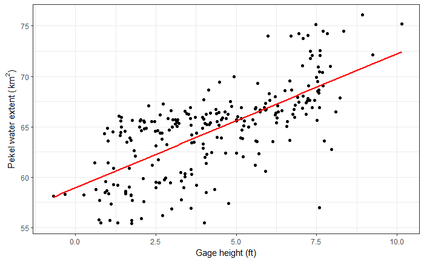

Replace missing Pekel data water values with the equation

$y = 58.9383998 + 1.3310656x_i$

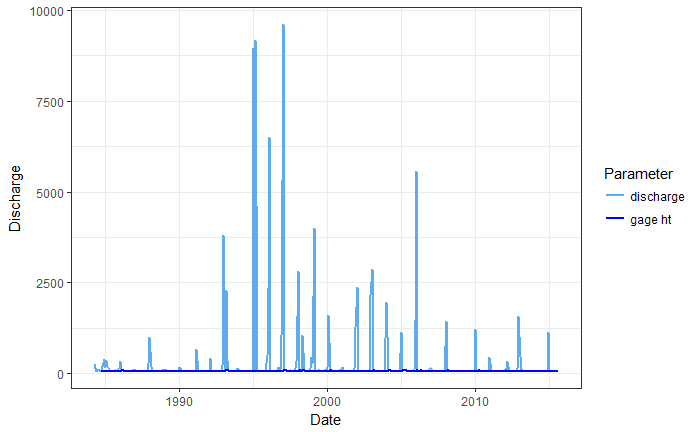

[figure not shown]